# Spatial regression using the spmoran package: Boston housing price data examples

Daisuke Murakami

2020/5/27

# Introduction

This package provides functions estimating Moran eigenvector-based spatial regression models. In concrete, this package implements standard spatial regression models and extensions, including spatially and non-spatially varying coefficient model, models with group effects, spatial unconditional quantile regression model, and low rank spatial econometric models. All these models are estimated computationally efficiently.

These models are are extensions of the random effects eigenvector spatial filtering (RE-ESF) approach that efficiently eliminates residual spatial dependence using a spatial process that is interpretable in terms of the Moran coefficient (MC; Moran’s I statistic). Below, I demonstrate spmoran using the baoston housin dataset. For further detail with another example, see https://arxiv.org/abs/1703.04467.

```r
library(spmoran)
```

# Moran eigenvector-based spatial regression models

## Spatial regression models

This section considers the following model:
$$y_i=\sum^K_{k=1}x_{i,k}\beta_k+f_{MC}(s_i)+\epsilon_i, \hspace{0.5cm}
\epsilon_i \sim N(0, \sigma^2),$$
which decomposes the explained variable $y_i$ observed at i-th sample site into trend $\sum^K_{k=1}x_{i,k}\beta_{i,k}$, spatial process $f_{MC}(s_i)$ depending on location $s_i$, and noise $\epsilon_i$. The spatial proess is required to eliminate residual spatial dependence, and estimate/infer regression coefficients $\beta_k$ appropreately. ESF and RE-ESF define $f_{MC}(s_i)$ using MC-based spatial process to eliminate residual spatial dependence efficiently. These processes are constructed using the Moran eigenvectors (MEs), which are orthogonal spatial basis (see Griffith, 2003).

### Eigenvector spatial filtering (ESF)

```r
require(spdep)
data(boston)
y       <- boston.c[, "CMEDV" ]
x       <- boston.c[,c("CRIM","ZN","INDUS", "CHAS", "NOX","RM", "AGE")]
coords<- boston.c[,c("LON","LAT")]

#########Distance-based ESF
meig    <- meigen(coords=coords)
```

## Spatially and non-spatially varying coefficient models

### Varying coefficient modeling

Influence from covariates can vary depending on covariate value. For example, distance to railway station might have strong impact on housing price if the distance is small while it might be weak if the distance is large. To capture such effect, the resf function estimates coefficients varying with respect to covariate value. I call such coefficients as non-spatially varying coefficients (NVCs). If nvc=TRUE, the resf function estimates the following model considering NSVs and residual spatial dependence:
$$y_i=\sum^K_{k=1}x_{i,k}\beta_{i,k}+f_{MC}(s_i)+\epsilon_i, \hspace{0.5cm}
\beta_{i,k}=b_k + f(x_{i,k}), \hspace{0.5cm} \epsilon_i \sim N(0, \sigma^2),$$
where $f(x_{i,k})$ is a smooth function of $x_{i,k}$ capturing the non-spatial influence.

Here is a code estimating a spatial NVC model (with selection of constant or NVC):

```r
res   <- resf(y = y, x = x, meig = meig, nvc=TRUE)
```

```r
res
```

```r
print(res, quote=TRUE)
```

```
## Call:
## resf(y = y, x = x, nvc = TRUE, meig = meig)
##
## ----Non-spatially varying coefficients (summary)----
##
## Coefficients:
##    Intercept          CRIM               ZN              INDUS              CHAS
##  Min.   :25.41   Min.   :-0.1822   Min.   :0.02042   Min.   :-0.2119   Min.   :1.375
##  1st Qu.:25.41   1st Qu.:-0.1822   1st Qu.:0.02042   1st Qu.:-0.2119   1st Qu.:1.375
##  Median :25.41   Median :-0.1822   Median :0.02042   Median :-0.2119   Median :1.375
##  Mean   :25.41   Mean   :-0.1822   Mean   :0.02042   Mean   :-0.2119   Mean   :1.375
##  3rd Qu.:25.41   3rd Qu.:-0.1822   3rd Qu.:0.02042   3rd Qu.:-0.2119   3rd Qu.:1.375
##  Max.   :25.41   Max.   :-0.1822   Max.   :0.02042   Max.   :-0.2119   Max.   :1.375
##       NOX               RM                AGE
##  Min.   :-0.463   Min.   :-0.78043   Min.   :-0.06742
##  1st Qu.: 6.083   1st Qu.:-0.40834   1st Qu.:-0.06742
##  Median : 7.792   Median :-0.16098   Median :-0.06742
##  Mean   : 7.074   Mean   : 0.03975   Mean   :-0.06742
##  3rd Qu.: 8.654   3rd Qu.: 0.19417   3rd Qu.:-0.06742
##  Max.   :11.517   Max.   : 2.49406   Max.   :-0.06742
##
## Statistical significance:
##                         Intercept CRIM  ZN INDUS CHAS NOX  RM AGE
## Not significant                 0    0 506     0    0 506 472   0
## Significant (10% level)         0    0   0     0  506   0   7   0
## Significant ( 5% level)         0    0   0     0    0   0  10   0
## Significant ( 1% level)       506  506   0   506    0   0  17 506
##
## ----Variance parameter------------------------
##
## Spatial effects (residuals):
##                      (Intercept)
## random_SE              3.6981527
## Moran.I/max(Moran.I)   0.4490228
##
## Non-spatially varying coefficients:
##           CRIM ZN INDUS CHAS      NOX        RM AGE
## random_SE    0  0     0    0 1.850518 0.2459548   0
##
## ----Error statistics--------------------------
##                      stat
## resid_SE        3.7949128
## adjR2(cond)     0.8271073
## rlogLik     -1478.6128728
## AIC          2983.2257457
## BIC          3038.1707224
```

By default, this fucntion selects constant or NVC through BIC minimization.“Non-spatially varying coefficients” in the “Variance parameter” section summarizes the estimated standard errors of the NVCs. Based on the result, coefficients on {NOX, RM} are NVCs, and coefficients on the others are constants. The NVC on RM, which is the 6-th covariates, is plotted as below. The solid line in the panel denotes the estimated NVC and the grey area denotes the 95 percent confidence interval. This plot shows that RM is positively statistically significant only if RM is large.

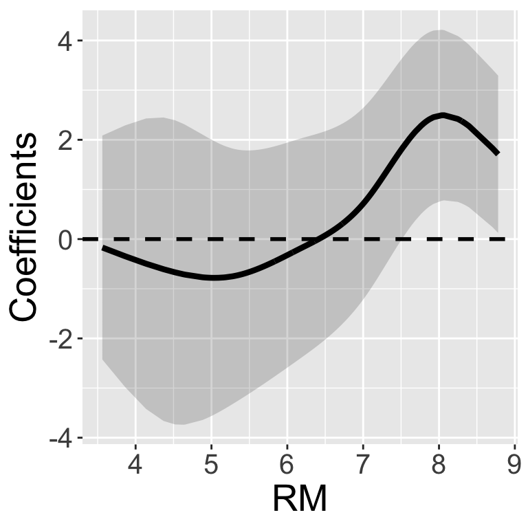

```r
plot_n(res,6)
```

The estimated spatial process $f_{MC}(s_i)$ can be plotted as

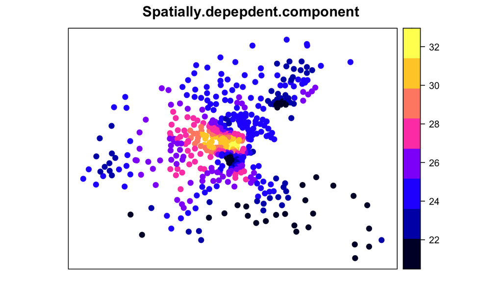

```r
plot_s(res)
```